Contents under Creative Commons BY 4.0 license and code under MIT license. © Julian Parra 2019. This material is part of the Master of Engineering program by Julian Parra at Universidad EAFIT.

# Response of a laterally-loaded pile foundation.

[figure not shown]

The following example discusses the design of a laterally-loaded pile foundation. The fundamental problem is that of finding the required length of a 2.20m diameter pile under an externally applied lateral load and bending moment. The mechanical properties of the soil deposit are given in table 01. The analysis is conducted for the maximum lateral load and bending moment under service conditions.

Units for this example are **[tonf-m]**.

**Input and output files for this problem are available in the examples folder of this REPO (notebooks\Examples).**

The main problem parameters are described next.

## Mechanical properties.

The following set of parameters defines the soil deposit at the site:

> - $Y :$ Depth.
> - $K_h:$ Lateral soil stiffness at a depth $Y$.
> - $\sigma_{ult}:$ Maximum stress in the soil at a depth $Y$.

[figure not shown]

> - Soil stiffness is represented by a bilinear $P$-$Y$ curve according to the variation with depth of $K_h$.

[figure not shown]

## Structural idealization for the pile

[figure not shown]

### Concrete drilled shaft

> - Element type: `2`
> - Pile cross sectional diameter: *2.20 m*
> - Material profile for the pile is concrete with an elastic modulus of *2527000 tonf/m²* and unit weight of *2.4 tonf/m³*

### Soil springs

> - Element type: `9`
> - Material profile for the springs according to the variation with depth of $K_h$:

[figure not shown]

The pile response was computed for a pile length of `7.0m`.

Identifiers for nodal points, elements and other problem dimensions are shown below:

[figure not shown]

The springs located at the `0.0m` and `7.0m` level employ `50%` of the total stiffness as per table 02.

```python
%matplotlib inline
import matplotlib.pyplot as plt
import numpy as np
import sympy as sym
from os import sys
sys.path.append("../source/")
from STRUCTURE import Struct_DYN
from postprocesor import *

# Execute analysis
displacement,folder,IBC,nodes,elements,ninc,T,MvarsGen,ILFGen = Struct_DYN("Examples/Ex_06/01_INPUT/")
```

```
----------------------
Number of nodes: 16
Number of elements: 15
Number of equations: 23
Number of equations after constraints: 23
----------------------
Natural periods of the system :  Not computed,static system solution
----------------------
Time step for solution: 0.01 sec
Number of time increments: 500
----------------------
Convergency reached after  1  iterations at increment  334  ( 3.34 sec)
Convergency reached after  1  iterations at increment  462  ( 4.62 sec)
Convergency reached after  1  iterations at increment  481  ( 4.81 sec)
Duration for system solution: 0:00:00.767947
Duration for the system's solution: 0:00:00.768939
Duration for post processing: 0:00:00
----------------------
Analysis terminated successfully!
----------------------
```

## Results

The evolution of the soil response in terms of the $P$-$Y$ curves for the springs undergoing plastic behavior is shown next. The plastified springs are identified by elements `8`,`9` and `14`.

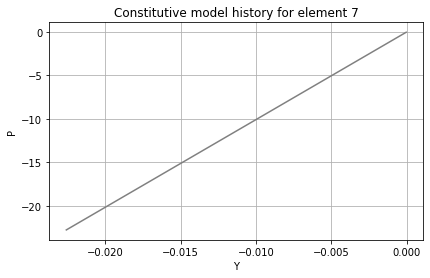

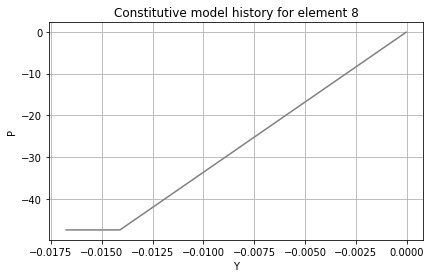

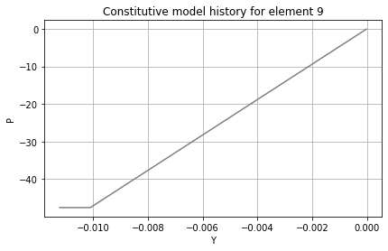

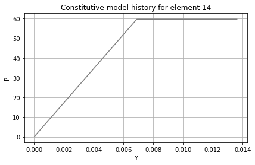

```python
histe = PlasModel(MvarsGen, Element = 7, xlabel = "Y", ylabel = "P")
histe = PlasModel(MvarsGen, Element = 8, xlabel = "Y", ylabel = "P")
histe = PlasModel(MvarsGen, Element = 9, xlabel = "Y", ylabel = "P")
histe = PlasModel(MvarsGen, Element = 14, xlabel = "Y", ylabel = "P")
```

On the other hand, element 14, corresponding to the spring associated to the soil layer with larger stiffness along the pile length undergoes plastic behavior since the found strains are larger than the plastic limit.

The predicted displacement time history along the horizontal direction for the node at the top of the pile is shown in the figure below:

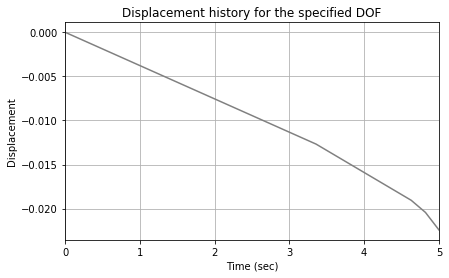

```python
fig   = NodalDispPLT(displacement[0,:], T, ninc, ylabel = "Displacement")
```

```python
from IPython.core.display import HTML
def css_styling():
    styles = open('./nb_style.css', 'r').read()
    return HTML(styles)
css_styling()
```